# Modelling interventions in R

Thanks to [Lisa White](http://www.tropmedres.ac/researchers/researcher/lisa-white), Nuffield Department of Medicine, Oxford University,

[Michael Meehan](https://research.jcu.edu.au/portfolio/emma.mcbryde), Australian Institute of Tropical Health & Medicine, James Cook University and

[Wirichada Pan-Ngum](http://www.tropmedres.ac/wirichada-pan-ngum), Department of Tropical Hygiene, Faculty of Tropical Medicine, Mahidol University.

Presented by [Michael Lydeamore](https://research.monash.edu/en/persons/michael-lydeamore), Department of Econometrics and Business Statistics, Monash University

# Summary

One of the most useful aspects of a mathematical model for infectious disease transmission is its capability to explore future intervention scenarios: what *could* be.

We will explore some R code for the 1st wave of COVID-19 in Thailand in 2020. This will involve the following parts:

1. A whiteboard discussion of how to include interventions in a model
2. Coding a model to capture the 1st wave interventions (emergency stage and curfew stage)
3. Estimating the effectiveness of the 1st wave interventions
4. Exploring counterfactuals
5. Practice building models to explicitly incorporate interventions of your choice in breakout groups

# Modelling Interventions

As always, we should set up a new script with a good header:

```r
# SPARK Modelling Short course
# 2023 Infectious Diseases Modelling

##################################
## MODELLING INTERVENTIONS IN R ##
##################################
```

Save this file somewhere in your `student_materials` folder with a meaningful name, like `session_seir_ode_covid`.

We also have to set the working directory. We can do this by pressing “To Source Location”, or using the `setwd()` command like we’ve done previously.

Now, let’s load some packages.

```r
library(dplyr)
library(deSolve)
library(ggplot2)
```

We’ll be making use of the first wave Thailand data. Here is a reminder of what the first wave in Thailand looked like:

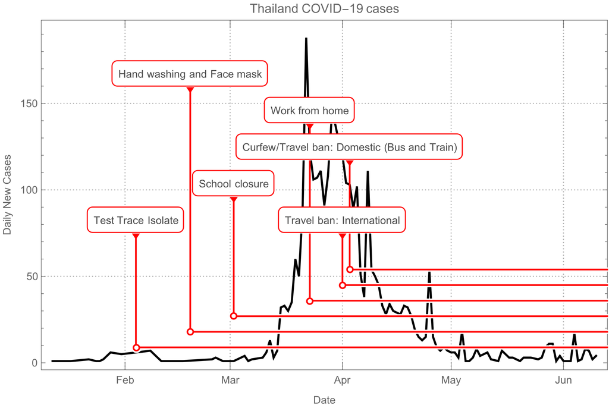

Let’s load back in the data, and have a look at a plot:

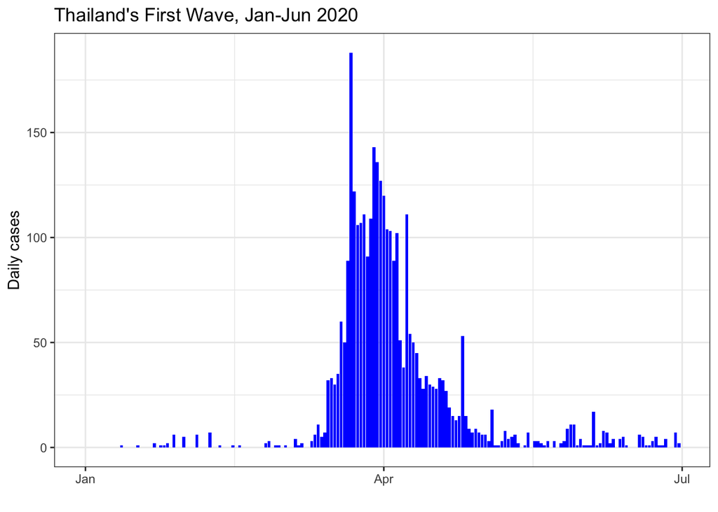

```r
first_wave <- read.csv("first_wave_TH.csv", colClasses = c("Date", "numeric", "numeric"))
first_wave$Date <- as.Date(first_wave$Date, format = "%Y-%m-%d")

ggplot(first_wave, aes(x = Date, y = Cases)) +
    geom_col(fill = "blue") +
    ylab("Daily cases") +
    xlab("") +
    ggtitle("Thailand's First Wave, Jan-Jun 2020") +
    theme_bw()
```

# Coding Interventions

```r
fitting_start_date <- as.Date("2020-03-07") # start of fitting window
emergency_start_date <- as.Date("2020-03-26") # Start of Emergency declaration
curfew_start_date <- as.Date("2020-04-03") # Start of Curfew
fitting_end_date <- as.Date("2020-05-13") # end of fitting window
```

We should filter down our data to the time period we want to fit to.

```r
outbreak <- first_wave %>%
    filter(Date >= fitting_start_date, Date <= fitting_end_date)
```

One of the most important things when you’re doing an optimisation is a decent initial guess at your parameter values. Luckily, in a previous session, we got a good estimate of R0, and we know a few things about how effective the various interventions might be.

```r
parameters <- c(
    R0 = 3.970588, # from the NM fitting session
    latent_period = 5, # Rounded from Trauer, J.M., Lydeamore, M.J., Dalton, G.W. et al. Understanding how Victoria, Australia gained control of its second COVID-19 wave. Nat Commun 12, 6266 (2021). https://doi.org/10.1038/s41467-021-26558-4
    infectious_period = 6, # Rounded from Trauer et al
    emergency_efficacy = 0.70, # guess, assuming Reff = (1-efficacy) * R0
    curfew_efficacy = 0.80 # guess
)
```

Since we’re using the same model from Sessions 4 and 5, we also need the same initial conditions, state variables and time window.

```r
# Initial conditions
Total_population <- 6.6e7 # Roughly population of Thailand
Initial_exposed <- 0 # Simplifying assumption
Initial_infectious <- 30.356868 # from the NM fitting session
Initial_recovered <- 0 # simplifying assumption
Initial_susceptible <- Total_population - Initial_exposed - Initial_infectious - Initial_recovered


# State variables
state <- c(
    Susceptible = Initial_susceptible,
    Exposed = Initial_exposed,
    Infectious = Initial_infectious,
    Recovered = Initial_recovered
)

# Time window
times <- seq(fitting_start_date, fitting_end_date, by = 1)
```

We’re going to use a slightly different implementation of the SEIR model from the previous session. See if you can spot the differences.

```r
COVID.intervention <- function(t, state, parameters) {
    with(as.list(c(state, parameters)), {

        # Calculate the total population size
        Total_population <- Susceptible + Exposed + Infectious + Recovered

        # Calculate intervention efficacy
        if (t < as.numeric(emergency_start_date - fitting_start_date)) {
            intervention_efficacy <- 0
        } else if (t >= as.numeric(emergency_start_date - fitting_start_date) &&
            t < as.numeric(curfew_start_date - fitting_start_date)) {
            intervention_efficacy <- emergency_efficacy
        } else {
            intervention_efficacy <- curfew_efficacy
        }

        # Calculate the effective reproduction number in the presence of interventions
        Reff <- (1 - intervention_efficacy) * R0 # assuming everyone starts susceptible

        # Calculate the average force of infection imposed on each susceptible individual
        force_of_infection <- Reff * Infectious / (Total_population * infectious_period)

        # Calculate the net (instantaneous) change in each state variable
        Susceptible_change <- -force_of_infection * Susceptible
        Exposed_change <- force_of_infection * Susceptible - Exposed / latent_period
        Infectious_change <- Exposed / latent_period - Infectious / infectious_period
        Recovered_change <- Infectious / infectious_period

        # Return net changes as list
        return(list(
            c(
                Susceptible_change,
                Exposed_change,
                Infectious_change,
                Recovered_change
            )
        ))
    })
}
```

What is different for this implementation compared to the implementation in session 4? Why?

Now, we wrap this function in a call to `ode` to solve our model, and give us the outputs we are interested in.

```r
# Wrapper function to solve model and tidy up output
solve.intervention.model <- function(y_ = state,
                                     times_ = times,
                                     func. = COVID.intervention,
                                     parms_ = parameters) {
    out <- ode(
        y = y_,
        times = as.numeric(times_ - times_[1]),
        func = func.,
        parms = parms_
    )

    # Calculate the prevalence, incidence and cumulative incidence (for comparison with data)
    out <- as.data.frame(out) %>%
        mutate(
            Incidence = Exposed / parms_["latent_period"],
            Cumulative_incidence = cumsum(Incidence) + Incidence[1],
            Population = Susceptible + Exposed + Infectious + Recovered,
            Prevalence = (Exposed + Infectious)/Population,
            Date = times_
        )

    return(as.data.frame(out))
}
```

We can solve this for our initial guess parameters, and see how it looks

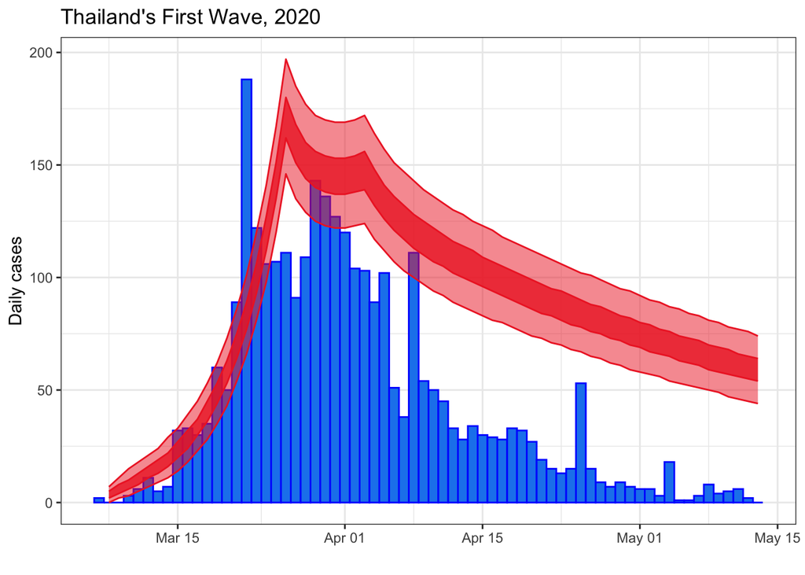

```r
# Run the model for out initial set of parameters
out_init <- solve.intervention.model()


# Make sure to add observational uncertainty
out_init <- out_init %>%
    mutate(
        lower50 = qpois(p = 0.25, lambda = Incidence), # 50% confidence interval (i.e., 25 - 75th centiles)
        upper50 = qpois(p = 0.75, lambda = Incidence),
        lower95 = qpois(p = 0.025, lambda = Incidence), # 95% confidence interval (i.e., 2.5 - 97.5th centiles)
        upper95 = qpois(p = 0.975, lambda = Incidence)
    )

# Plot initial estimate
ggplot(outbreak) +
    geom_col(aes(x = Date, y = Cases), width = 1, fill = "dodgerblue2", colour = "blue") +
    geom_ribbon(
        data = out_init[-1, ], aes(x = Date, ymin = lower50, ymax = upper50),
        fill = "firebrick2", colour = "firebrick2", alpha = 0.8
    ) +
    geom_ribbon(
        data = out_init[-1, ], aes(x = Date, ymin = lower95, ymax = upper95),
        fill = "firebrick2", colour = "firebrick2", alpha = 0.5
    ) +
    ylab("Daily cases") +
    xlab("") +
    ggtitle("Thailand's First Wave, 2020") +
    theme_bw()
```

# Model calibration

So we have written code that can solve our model for a given set of parameters. Now, just like we did last time, we can use maximum likelihood estimation to determine the optimal parameters for our model.

**Parameter scaling**

Optimisation algorithms rely on parameters being able to take on **any** value (i.e. $(-\infty, \infty)$)

Our effectiveness parameters are defined as “reductions in transmission”, which means they are bounded between 0 and 1. To put them in the form the optimiser is expecting, we’ll use the *logit* transform.

```r
logit <- function(x) {
    return(log(x / (1 - x)))
}

# And its inverse
inverse.logit <- function(x) {
    return(exp(x) / (1 + exp(x)))
}
```

And now we’re ready to write our negative log likelihood function.

```r
negative.log.likelihood <- function(transformed_parameters, # assumes logit form of parameters -- per Wednesday arvo session
                                    data = outbreak$Cases[-1],
                                    state_ = state,
                                    times_ = times,
                                    func. = COVID.intervention, # note this is our ode solver
                                    parms_base = parameters) {

    # Back-transform model parameters (inverse logit)
    parms_base[c("emergency_efficacy", "curfew_efficacy")] <-
        inverse.logit(transformed_parameters[c("emergency_efficacy", "curfew_efficacy")])

    # Solve model with updated parameters
    out <- solve.intervention.model(
        state_,
        times_,
        func.,
        parms_base
    )

    return(-sum(dpois(
        x = data,
        lambda = out$Incidence[-1],
        log = TRUE
    ))) # Poisson observation model
}
```

The complicated part of this is transforming back and forth between the logit-transformed parameters, and the “actual” parameters that we care about. We have to make sure to transform before we start.

```r
init_parameters <- c(logit(parameters[c(
    "emergency_efficacy",
    "curfew_efficacy"
)]))

# Calculate initial negative log-likelihood
negative.log.likelihood(init_parameters)
```

```
[1] 1865.599
```

```r
negative_log_likelihood_initial <- -sum(dpois(
    x = outbreak$Cases[-1],
    lambda = out_init$Incidence[-1], # This is from the previous section!
    log = TRUE
))
negative_log_likelihood_initial
```

```
[1] 1865.599
```

Now we’re in a place to use `optim` again, just like we’ve done previously.

```r
optim_NM <- optim(
    par = init_parameters,
    fn = negative.log.likelihood,
    method = "Nelder-Mead",
    hessian = TRUE
)

# Check for convergence
optim_NM$convergence # 0 - converged; nonzero - failed
```

```
[1] 0
```

```r
# Back-transform parameters
c(inverse.logit(optim_NM$par[c(
    "emergency_efficacy",
    "curfew_efficacy"
)]))
```

```
emergency_efficacy    curfew_efficacy
         0.7907816          0.9164450
```

```r
# Inspect the optimal negative log-likelihood
optim_NM$value
```

```
[1] 372.4239
```

This looks pretty good, and so we can be reasonably happy we’ve reached an optimal solution. Now that we have a solution, let’s plot it.

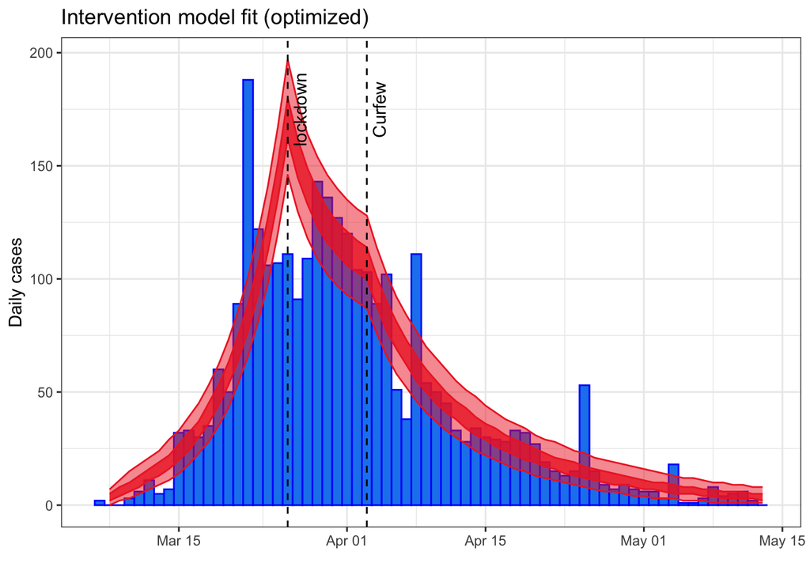

```r
optimal_parameters <- parameters
optimal_parameters[c(
    "emergency_efficacy",
    "curfew_efficacy"
)] <- inverse.logit(optim_NM$par[c(
    "emergency_efficacy",
    "curfew_efficacy"
)])



# Solve the model given the optimal parameters and initial conditions
optimal_solution <- solve.intervention.model(
    y_ = state,
    times_ = times,
    func. = COVID.intervention,
    parms = optimal_parameters
)


# Calculate the observational confidence intervals
optimal_solution <- optimal_solution %>%
    mutate(
        lower50 = qpois(p = 0.25, lambda = Incidence), # 50% confidence interval (i.e., 25 - 75th centiles)
        upper50 = qpois(p = 0.75, lambda = Incidence),
        lower95 = qpois(p = 0.025, lambda = Incidence), # 95% confidence interval (i.e., 2.5 - 97.5th centiles)
        upper95 = qpois(p = 0.975, lambda = Incidence)
    )

ggplot(outbreak) +
    geom_col(
        aes(x = Date, y = Cases),
        width = 1.0,
        fill = "dodgerblue2",
        colour = "blue"
    ) +
    geom_ribbon(
        data = optimal_solution[-1, ],
        aes(x = Date, ymin = lower50, ymax = upper50),
        fill = "firebrick2", colour = "firebrick2", alpha = 0.8
    ) +
    geom_ribbon(
        data = optimal_solution[-1, ],
        aes(x = Date, ymin = lower95, ymax = upper95),
        fill = "firebrick2", colour = "firebrick2", alpha = 0.5
    ) +
    ylab("Daily cases") +
    xlab("") +
    ggtitle("Intervention model fit (optimized)") +
    geom_vline(
        aes(xintercept = emergency_start_date),
        linetype = "dashed"
    ) +
    geom_vline(
        aes(xintercept = curfew_start_date),
        linetype = "dashed"
    ) +
    annotate(
        geom = "text",
        label = c("lockdown", "Curfew"),
        x = c(emergency_start_date, curfew_start_date),
        y = c(175, 175),
        angle = 90,
        vjust = 1.5
    ) +
    theme_bw()
```

Great! The fit looks reasonable, at least visually. To report on parameter uncertainty, we use the same tricks as last time, with the square root of the diagonals of the hessian matrix.

```r
covar_matrix <- solve(optim_NM$hessian)
std_errors <- sqrt(diag(covar_matrix))
estimates_transformed <- data.frame(
    estimate = optim_NM$par,
    std_error = std_errors
) %>%
    dplyr::mutate(
        lower95CI = estimate - 1.96 * std_error,
        upper95CI = estimate + 1.96 * std_error
    )
estimates_transformed
```

```
                   estimate  std_error lower95CI upper95CI
emergency_efficacy 1.329643 0.05962182  1.212785  1.446502
curfew_efficacy    2.394996 0.04658667  2.303686  2.486306
```

```r
# Back-transform estimates and confidence intervals
estimates <- inverse.logit(estimates_transformed[, -2])
estimates
```

```
                    estimate lower95CI upper95CI
emergency_efficacy 0.7907816 0.7707913 0.8094595
curfew_efficacy    0.9164450 0.9091819 0.9231762
```

What do you see in these plots and estimates? Which type of uncertainty does this capture? What other types of uncertainty should we consider?

# Exploring counterfactuals

Now we have a model for the COVID-19 transmission in Thailand, and we have estimates of how effective the two stages of interventions were (emergency and curfew), we can now explore what *could* have happened, or the **counterfactuals**.

What could have happened if no intervention was applied? What could have happened if we started the emergency stage earlier? What other interesting counterfactual scenarios could we explore? Which of the scenarios you suggested previously might be of interest to the general public and why? Would the scenarios of interest to decision makers be different? If so, how and why?